# hw04: Tidy data and joins

Load the required packages:

```r
library(gapminder)
library(tidyverse)
```

# Ex1. Univariate data reshaping

## Option 1 - Exploring life expectancy for Australia and Japan

### A tibble with one row per year, and columns for life expectancy for two or more countries.

```r
(Ex1<- gapminder %>%
  select(country, lifeExp, year) %>%
  filter(country == "Australia" | country == "Japan") %>%
  pivot_wider(id_cols = year,
              names_from = country,
              values_from = lifeExp))
```

```
## # A tibble: 12 x 3
##     year Australia Japan
##    <int>     <dbl> <dbl>
##  1  1952      69.1  63.0
##  2  1957      70.3  65.5
##  3  1962      70.9  68.7
##  4  1967      71.1  71.4
##  5  1972      71.9  73.4
##  6  1977      73.5  75.4
##  7  1982      74.7  77.1
##  8  1987      76.3  78.7
##  9  1992      77.6  79.4
## 10  1997      78.8  80.7
## 11  2002      80.4  82
## 12  2007      81.2  82.6
```

### A scatter plot of the life expectancy of Japan against Australia

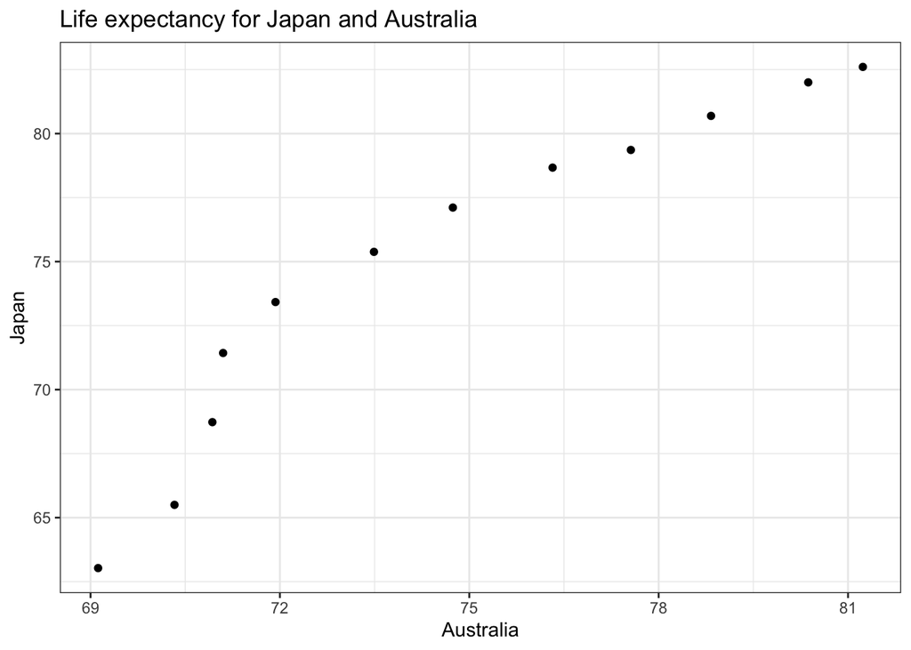

```r
ggplot(Ex1, aes(Australia, Japan))+
  geom_point()+
  ggtitle("Life expectancy for Japan and Australia")+
  theme_bw()
```

#### *Figure 1. Life expectancy of Japan against Australia.*

### Re-lengthen the data

```r
Ex1 %>%
  pivot_longer(cols = c(Australia, Japan),
               names_to = "country",
               values_to = "lifeExp")
```

```
## # A tibble: 24 x 3
##     year country   lifeExp
##    <int> <chr>       <dbl>
##  1  1952 Australia    69.1
##  2  1952 Japan        63.0
##  3  1957 Australia    70.3
##  4  1957 Japan        65.5
##  5  1962 Australia    70.9
##  6  1962 Japan        68.7
##  7  1967 Australia    71.1
##  8  1967 Japan        71.4
##  9  1972 Australia    71.9
## 10  1972 Japan        73.4
## # … with 14 more rows
```

# Ex2. Multivariate data re-shaping

## Option 1

### A tibble for the life expectancy and GDP per capita for Australia and Japan

```r
(Ex2<- gapminder %>%
  select(country, lifeExp, year, gdpPercap) %>%
   filter(country == "Australia" | country == "Japan") %>%
  pivot_wider(id_cols = year,
              names_from = c(country),
              names_sep = "_",
              values_from = c("lifeExp", "gdpPercap")))
```

```
## # A tibble: 12 x 5
##     year lifeExp_Australia lifeExp_Japan gdpPercap_Austral… gdpPercap_Japan
##    <int>             <dbl>         <dbl>              <dbl>           <dbl>
##  1  1952              69.1          63.0             10040.           3217.
##  2  1957              70.3          65.5             10950.           4318.
##  3  1962              70.9          68.7             12217.           6577.
##  4  1967              71.1          71.4             14526.           9848.
##  5  1972              71.9          73.4             16789.          14779.
##  6  1977              73.5          75.4             18334.          16610.
##  7  1982              74.7          77.1             19477.          19384.
##  8  1987              76.3          78.7             21889.          22376.
##  9  1992              77.6          79.4             23425.          26825.
## 10  1997              78.8          80.7             26998.          28817.
## 11  2002              80.4          82               30688.          28605.
## 12  2007              81.2          82.6             34435.          31656.
```

### Re-lengthen the data

```r
Ex2 %>%
  pivot_longer(cols =  -year,
               names_to = c(".value", "country"),
               names_sep = "_")
```

```
## # A tibble: 24 x 4
##     year country   lifeExp gdpPercap
##    <int> <chr>       <dbl>     <dbl>
##  1  1952 Australia    69.1    10040.
##  2  1952 Japan        63.0     3217.
##  3  1957 Australia    70.3    10950.
##  4  1957 Japan        65.5     4318.
##  5  1962 Australia    70.9    12217.
##  6  1962 Japan        68.7     6577.
##  7  1967 Australia    71.1    14526.
##  8  1967 Japan        71.4     9848.
##  9  1972 Australia    71.9    16789.
## 10  1972 Japan        73.4    14779.
## # … with 14 more rows
```

# Ex3. Table joins

First read in the data from github

```r
guest <- read_csv("https://raw.githubusercontent.com/STAT545-UBC/Classroom/master/data/wedding/attend.csv")
email <- read_csv("https://raw.githubusercontent.com/STAT545-UBC/Classroom/master/data/wedding/emails.csv")
```

## 3.1 For each guest in the guestlist (guest tibble), add a column for email address, which can be found in the email tibble.

First I created an object that is the email list in long format, with only one observation (name) per e-mail. The object ‘email.guest’ is then created by joining the guest list with the email list by name.

```r
(email.long <- email %>%
  separate_rows(guest, sep = ", ") %>%
   rename(name = guest))
```

```
## # A tibble: 28 x 2
##    name            email
##    <chr>           <chr>
##  1 Sommer Medrano  sommm@gmail.com
##  2 Phillip Medrano sommm@gmail.com
##  3 Blanka Medrano  sommm@gmail.com
##  4 Emaan Medrano   sommm@gmail.com
##  5 Blair Park      bpark@gmail.com
##  6 Nigel Webb      bpark@gmail.com
##  7 Sinead English  singlish@hotmail.ca
##  8 Ayra Marks      marksa42@gmail.com
##  9 Jolene Welsh    jw1987@hotmail.com
## 10 Hayley Booker   jw1987@hotmail.com
## # … with 18 more rows
```

```r
(email.guest <- guest %>%
  left_join(email.long, by = "name"))
```

```
## # A tibble: 30 x 8
##    party name  meal_wedding meal_brunch attendance_wedd… attendance_brun…
##    <dbl> <chr> <chr>        <chr>       <chr>            <chr>
##  1     1 Somm… PENDING      PENDING     PENDING          PENDING
##  2     1 Phil… vegetarian   Menu C      CONFIRMED        CONFIRMED
##  3     1 Blan… chicken      Menu A      CONFIRMED        CONFIRMED
##  4     1 Emaa… PENDING      PENDING     PENDING          PENDING
##  5     2 Blai… chicken      Menu C      CONFIRMED        CONFIRMED
##  6     2 Nige… <NA>         <NA>        CANCELLED        CANCELLED
##  7     3 Sine… PENDING      PENDING     PENDING          PENDING
##  8     4 Ayra… vegetarian   Menu B      PENDING          PENDING
##  9     5 Atla… PENDING      PENDING     PENDING          PENDING
## 10     5 Denz… fish         Menu B      CONFIRMED        CONFIRMED
## # … with 20 more rows, and 2 more variables: attendance_golf <chr>,
## #   email <chr>
```

## 3.2 Who do we have emails for, yet are not on the guestlist?

```r
email.long %>%
  anti_join(guest)
```

```
## # A tibble: 3 x 2
##   name            email
##   <chr>           <chr>
## 1 Turner Jones    tjjones12@hotmail.ca
## 2 Albert Marshall themarshallfamily1234@gmail.com
## 3 Vivian Marshall themarshallfamily1234@gmail.com
```

## 3.3 Make a guestlist that includes everyone we have emails for (in addition to those on the original guestlist).

This is a list that is a full guestlist of everyone there are emails for. I joined the email.long dataframe with the guest dataframe so that everyone we have emails is included.

```r
(full.list <- guest %>%
  full_join(email.long))
```

```
## # A tibble: 33 x 8
##    party name  meal_wedding meal_brunch attendance_wedd… attendance_brun…
##    <dbl> <chr> <chr>        <chr>       <chr>            <chr>
##  1     1 Somm… PENDING      PENDING     PENDING          PENDING
##  2     1 Phil… vegetarian   Menu C      CONFIRMED        CONFIRMED
##  3     1 Blan… chicken      Menu A      CONFIRMED        CONFIRMED
##  4     1 Emaa… PENDING      PENDING     PENDING          PENDING
##  5     2 Blai… chicken      Menu C      CONFIRMED        CONFIRMED
##  6     2 Nige… <NA>         <NA>        CANCELLED        CANCELLED
##  7     3 Sine… PENDING      PENDING     PENDING          PENDING
##  8     4 Ayra… vegetarian   Menu B      PENDING          PENDING
##  9     5 Atla… PENDING      PENDING     PENDING          PENDING
## 10     5 Denz… fish         Menu B      CONFIRMED        CONFIRMED
## # … with 23 more rows, and 2 more variables: attendance_golf <chr>,
## #   email <chr>
```